# ESM 204 HW 4

Caroline Shepherd

5/23/2022

```r
# Read in the data for damages (cost in $) and warming (in degrees C)

damages <- read_csv(here("damages.csv")) %>%
  clean_names()

warming <- read_csv(here("warming.csv")) %>%
  clean_names %>%
  select(year:warming_pulse)
```

# Homework 4: Updating SCC

The first, “damages.csv” provides new model estimates of the annual total damages from climate change at different levels of warming (in degrees C). The second dataset, “warming.csv” contains estimates of a baseline future climate trajectory (in degrees C) until 2100, and a second trajectory that adds a one-time pulse of CO2 today to the atmosphere. The pulse is 35 billion tons of carbon, which is roughly equal to annual global emissions. You can think of this as a “small” one-time pulse in carbon emissions.1

# Question 1

Using damages.csv, estimate a quadratic damage function relating the dollar value of damages to the change in global mean temperature. Estimate a model with a zero intercept because damages by construction must equal zero when there is no climate change. Plot your estimated damage function, overlaid with a scatterplot of the underlying data.

```r
# Pulse = 35 billion tons of carbon
pulse <- 35000000000

# Making a new column with warming squared to derive quadratic equation later
damages$warming2 <- damages$warming^2

# Create a linear regression model of original warming and the squared warming data
damages_lm <- lm(damages ~ 0 + warming + warming2, data = damages)
summary(damages_lm)
```

```
##
## Call:
## lm(formula = damages ~ 0 + warming + warming2, data = damages)
##
## Residuals:
##        Min         1Q     Median         3Q        Max
## -1.384e+14 -1.637e+13  8.574e+11  1.752e+13  1.416e+14
##
## Coefficients:
##            Estimate Std. Error t value Pr(>|t|)
## warming  -1.060e+12  9.625e+11  -1.101    0.271
## warming2  1.941e+13  1.585e+11 122.431   <2e-16 ***
## ---
## Signif. codes:  0 '***' 0.001 '**' 0.01 '*' 0.05 '.' 0.1 ' ' 1
##
## Residual standard error: 3.466e+13 on 554 degrees of freedom
## Multiple R-squared:  0.994,  Adjusted R-squared:  0.9939
## F-statistic: 4.563e+04 on 2 and 554 DF,  p-value: < 2.2e-16
```

```r
# Estimate demand function by creating quadratic equation using the linear regression model
damages_funct <- function(x){
  damages_lm$coefficients[1]*x+damages_lm$coefficients[2]*x^2
}

# Quadratic equation:
extract_eq(model = damages_lm, use_coefs = TRUE, coef_digits = 2)
```

$$\operatorname{\widehat{damages}} = -1059530137756.23(\operatorname{warming}) + 19409275730643.3(\operatorname{warming2})$$

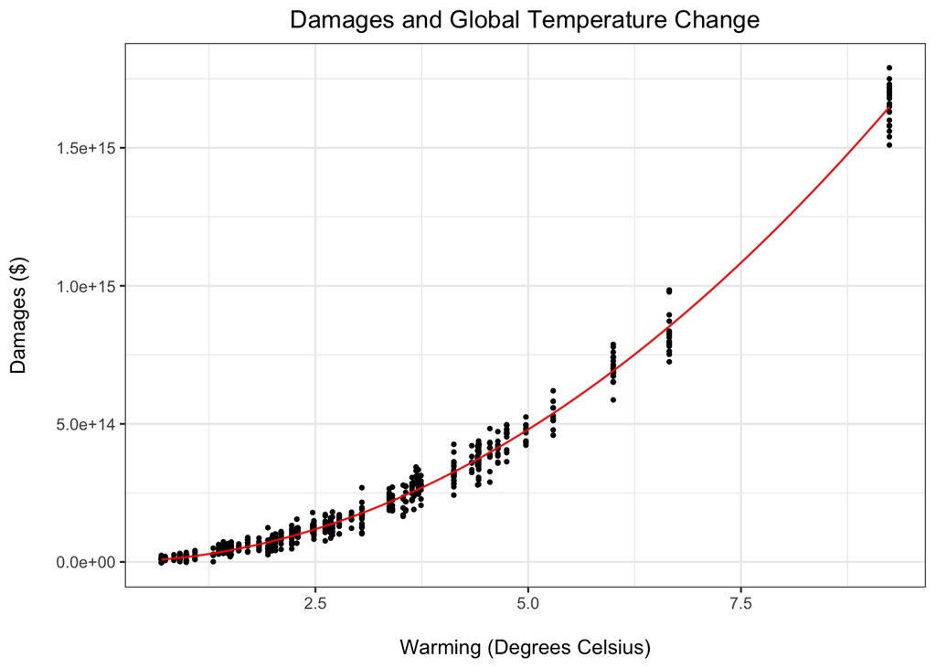

```r
# Plot estimated damage function, overlaid with a scatterplot of the underlying data
ggplot(data = damages, aes(x = warming, y = damages)) +
  geom_point(size = .75) +
  theme_bw() +
  theme(plot.title = element_text(hjust = 0.5),
        legend.position = "top") +
  labs(x = "\nWarming (Degrees Celsius)", y = "Damages ($)\n", title = "Damages and Global Temperature Change") +
  stat_function(fun = damages_funct, color = "red")
```

# Question 2

Use warming.csv and your estimated damage function to predict damages in each year under the baseline climate and the pulse scenario. Make four plots: (1) damages over time without the pulse, (2) damages over time with the pulse, (3) the difference in damages over time that arises from the pulse, and (4) the difference in damages over time from the pulse per ton of CO2 (you can assume that each ton of the pulse causes the same amount of damage).

```r
# Create new columns using lm model to depict each scenario from question 2
warming_damages <- warming %>%
  mutate(damages_baseline = damages_funct(warming_baseline)) %>% # 1) changes over time w/o pulse
  mutate(damages_pulse = damages_funct(warming_pulse)) %>% # 2) damages over time w/ pulse
  mutate(damages_difference = damages_pulse - damages_baseline) %>% # 3) diff in damages arising from pulse
  mutate(damages_difference_co2 = damages_difference/pulse) # 4) diff in damages over time w/ pulse/ton C02
```

### Plotting Scenario #1

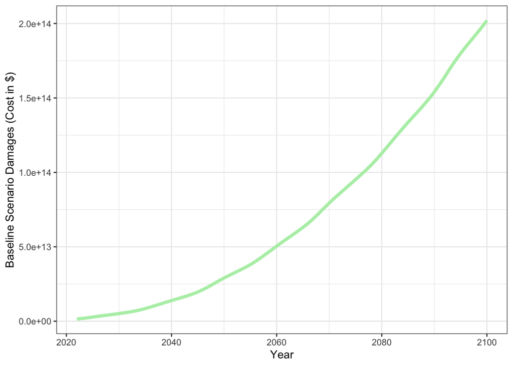

```r
# Scenario 1: changes over time w/o pulse
ggplot(data = warming_damages, aes(x = year, y = damages_baseline)) +
  geom_line(color = "darkseagreen2", size = 1.5) +
  theme_bw() +
  labs(x = "Year", y = "Baseline Scenario Damages (Cost in $)")
```

**Figure 2.0:** This figure depicts changes in damages and warming over time without the pulse input.

### Plotting Scenario #2

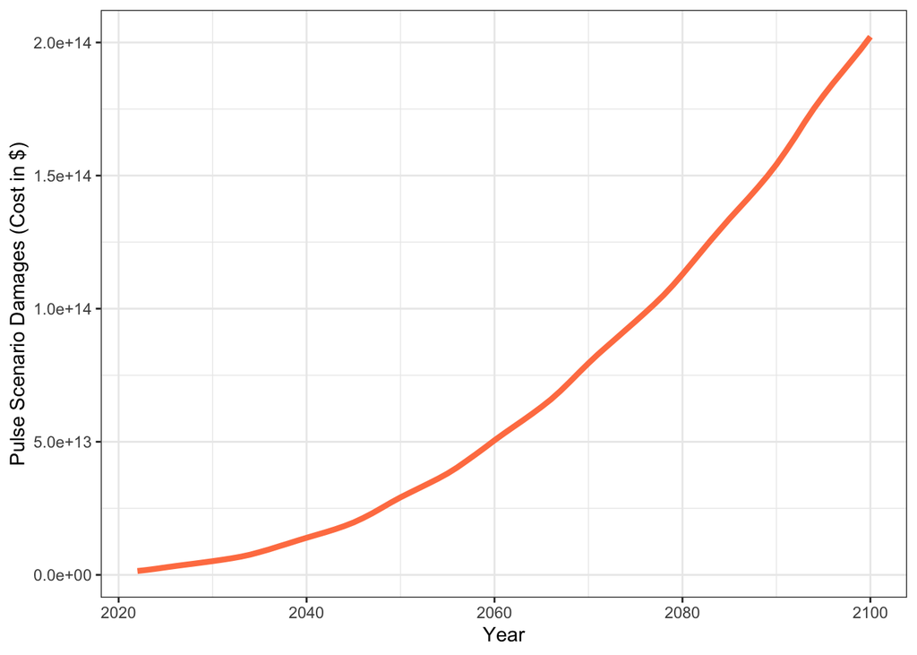

```r
# Scenario 2: damages over time w/ pulse
ggplot(data = warming_damages, aes(x = year, y = damages_pulse)) +
  geom_line(color = "coral", size = 1.5) +
  theme_bw() +
  labs(x = "Year", y = "Pulse Scenario Damages (Cost in $)")
```

**Figure 2.1:** This figure depicts damages from warming over time with the inclusion of the pulse input.

### Plotting Scenario #3

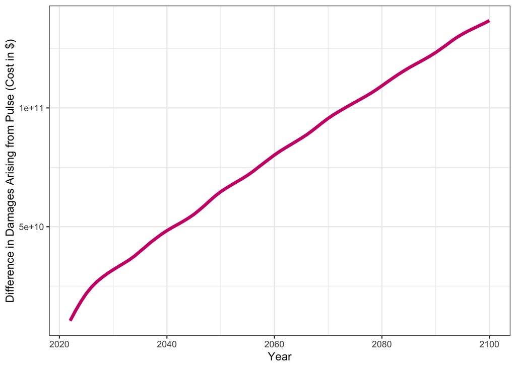

```r
# Scenario 3: difference in damages arising from pulse
ggplot(data = warming_damages, aes(x = year, y = damages_difference)) +
  geom_line(color = "deeppink3", size = 1.5) +
  theme_bw() +
  labs(x = "Year", y = "Difference in Damages Arising from Pulse (Cost in $)")
```

**Figure 2.2:** This figure depicts the difference in damages arising from the inclusion of the pulse input.

### Plotting Scenario #4

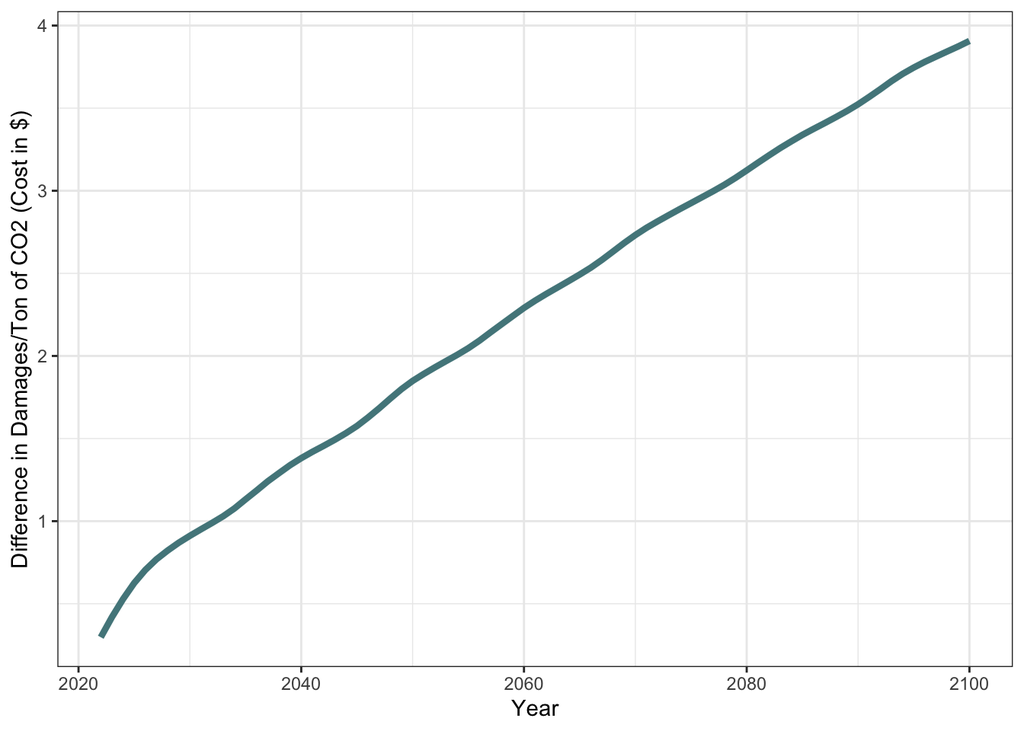

```r
# Scenario 4: the difference in damages over time from the pulse per ton of CO2
ggplot(data = warming_damages, aes(x = year, y = damages_difference_co2)) +
  geom_line(color = "cadetblue4", size = 1.5) +
  theme_bw() +
  labs(x = "Year", y = "Difference in Damages/Ton of CO2 (Cost in $)")
```

**Figure 2.3**: This figure depicts the difference in damages over time from the pulse/ton of C02, assuming that each ton of the pulse results in an equal amount of damage.

# Question 3

The SCC is the present discounted value of the stream of future damages caused by one additional ton of CO2. The Obama Administration used a discount rate of 3% to discount damages. Recently, New York State used a discount rate of 2%. Calculate and make a plot of the SCC (y-axis) against the discount rate (x-axis) for a reasonable range of discount rates. Explain the intuition for how the discount rate affects the SCC.

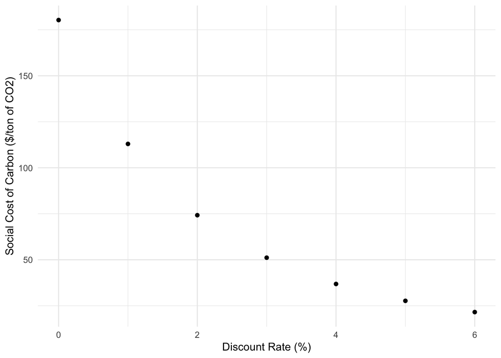

```r
# Set baseline year to levels from 2022
 scc_function <- function(discount_rate){
   warming_damages_scc %>%
     mutate(pv = damages_difference_co2/((1+discount_rate)^(-(year-baseline_year))))

   present_value = sum(warming_damages_scc$pv)
   return(present_value)
 }

baseline_year <- 2022

# Calculating warming damages scc based on 1-6% discount rates. Using mutate to create a new column for each discount rate.

warming_damages_scc <- warming_damages %>%
  select(year, damages_difference_co2) %>%
  mutate(pv_0 = damages_difference_co2*((1+0.0)^(-(year-baseline_year)))) %>%
  mutate(pv_1 = damages_difference_co2*((1+0.01)^(-(year-baseline_year)))) %>%
  mutate(pv_2 = damages_difference_co2*((1+0.02)^(-(year-baseline_year)))) %>%
  mutate(pv_3 = damages_difference_co2*((1+0.03)^(-(year-baseline_year)))) %>%
  mutate(pv_4 = damages_difference_co2*((1+0.04)^(-(year-baseline_year)))) %>%
  mutate(pv_5 = damages_difference_co2*((1+0.05)^(-(year-baseline_year)))) %>%
  mutate(pv_6 = damages_difference_co2*((1+0.06)^(-(year-baseline_year))))

discount_rates <- c(0,1,2,3,4,5,6)

scc_calc <- c(sum(warming_damages_scc$pv_0),sum(warming_damages_scc$pv_1),
                       sum(warming_damages_scc$pv_2),sum(warming_damages_scc$pv_3),
                       sum(warming_damages_scc$pv_4),sum(warming_damages_scc$pv_5),
                       sum(warming_damages_scc$pv_6))

scc_df <- data.frame(discount_rates,
                     scc_calc)

ggplot(data = scc_df, aes(x = discount_rates, y = scc_calc)) +
  geom_point(color = "black") +
  theme_minimal() +
  labs(x = "Discount Rate (%)", y = "Social Cost of Carbon ($/ton of CO2)")
```

# Question 4

The National Academies of Sciences, Engineering, and Medicine advised the government in a 2017 report to use the Ramsey Rule when discounting within the SCC calculation: r = ρ + ηg Using ρ = 0.001, η = 2, and g = 0.01, what is the SCC? Locate this point on your graph from above.

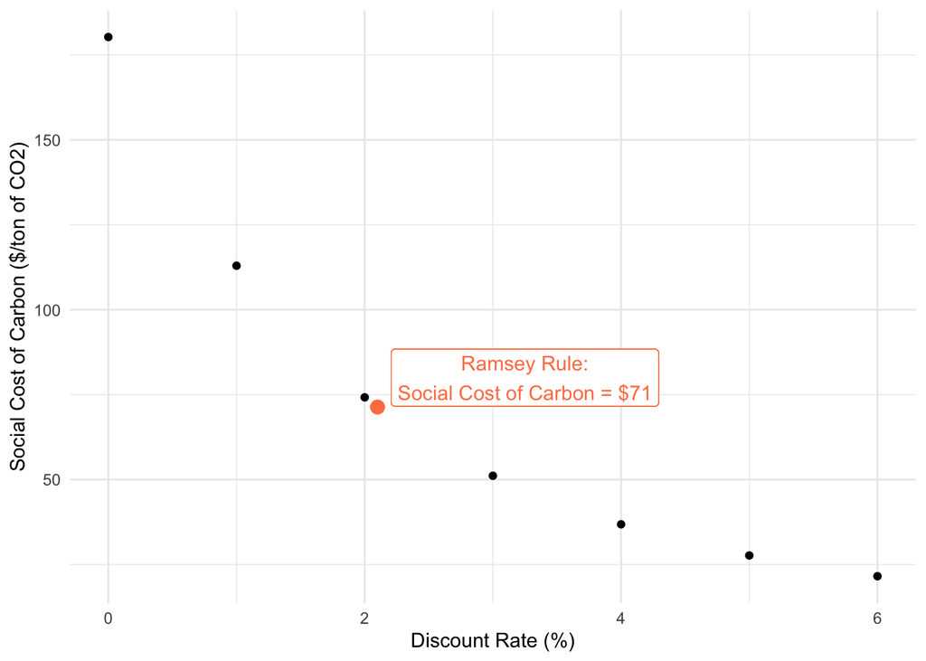

```r
#Use the ramsey rule to calculate the discount rate for SCC
discount_rate_ramsey <- (0.001+2*0.01)*100
warming_damages_ramsey <- warming_damages %>%
  select(year, damages_difference_co2) %>%
  mutate(pv_ramsey = damages_difference_co2*((1+(discount_rate_ramsey/100))^(-(year-baseline_year))))
scc_ramsey <- sum(warming_damages_ramsey$pv_ramsey)

ggplot(data = scc_df, aes(x = discount_rates, y = scc_calc)) +
  geom_point(color = "black") +
  theme_minimal() +
  labs(x = "Discount Rate (%)", y = "Social Cost of Carbon ($/ton of CO2)") +
  geom_label(aes(x=3.25, label="Ramsey Rule:\nSocial Cost of Carbon = $71", y=80), color="coral") +
  geom_point(aes(x = 2.1, y = 71.35), color = "coral", size = 3)
```

**Figure 4:** By using the Ramsey Rule, I found that the best discount rate to find the SCC would be 2.1%, making the updated SCC equal to approximately $71. This point is depicted on the figure above.

# Question 5

Now suppose there are two possible climate policies that can be pursued. Policy A is business as usual and Policy B is to take immediate and strong action on climate change. Use these facts -If you undertake Policy A there are two possible outcomes. Either warming will occur as in the “baseline” (i.e. “no-pulse”) dataset above (this happens with probability 0.5) or warming each year will be 1.5 times that in the “baseline” dataset (with probability 0.5). -Under Policy B, warming will continue until 2050 as in the “baseline” dataset, and then will stabilize at 1.29 degrees and stay that way forever. -Society is risk neutral -Use a discount rate of 2%

```r
# Setting discount rate to 0.20, per question instructions
discount_rate_policy <- 0.02

#Policy A
warming_damages_policy_a <- warming_damages %>%
  select(year, warming_baseline, damages_baseline) %>%
  mutate(damages_2 = damages_funct(1.5*warming_baseline)) %>%
  mutate(pv_baseline = damages_baseline*(1+discount_rate_policy)^(-(year-baseline_year))) %>%
  mutate(pv_2 = damages_2*(1+discount_rate_policy)^(-(year-baseline_year)))

# Finding total cost of policy A
policy_a <- sum(warming_damages_policy_a$pv_baseline)*0.5 +
             sum(warming_damages_policy_a$pv_2)*0.5

#Policy B
warming_damages_policy_b <- warming_damages %>%
  select(year, warming_baseline)

for (i in 30:79){
  warming_damages_policy_b$warming_baseline[i]=1.29
}

warming_damages_policy_b <- warming_damages_policy_b %>%
  mutate(damages_b = damages_funct(warming_baseline)) %>%
  mutate(pv_b = damages_b*(1+discount_rate_policy)^(-(year-baseline_year)))

# Finding costs of policy B
policy_b <- sum(warming_damages_policy_b$pv_b)
```

Expected Net Benefit = 𝑝1(𝐵1 − 𝐶1) + 𝑝2(𝐵2 − 𝐶2) + … + 𝑝𝑛(𝐵𝑛 − 𝐶𝑛)

### Policy A: Business as Usual

The expected present value of damages up to 2100 of policy A is **$3.0232455^{15}**.

### Policy B: Taking Immediate Action on Climate Change

The expected present value of damages up to 2100 of policy B is **$ 7.8667128^{14}**.

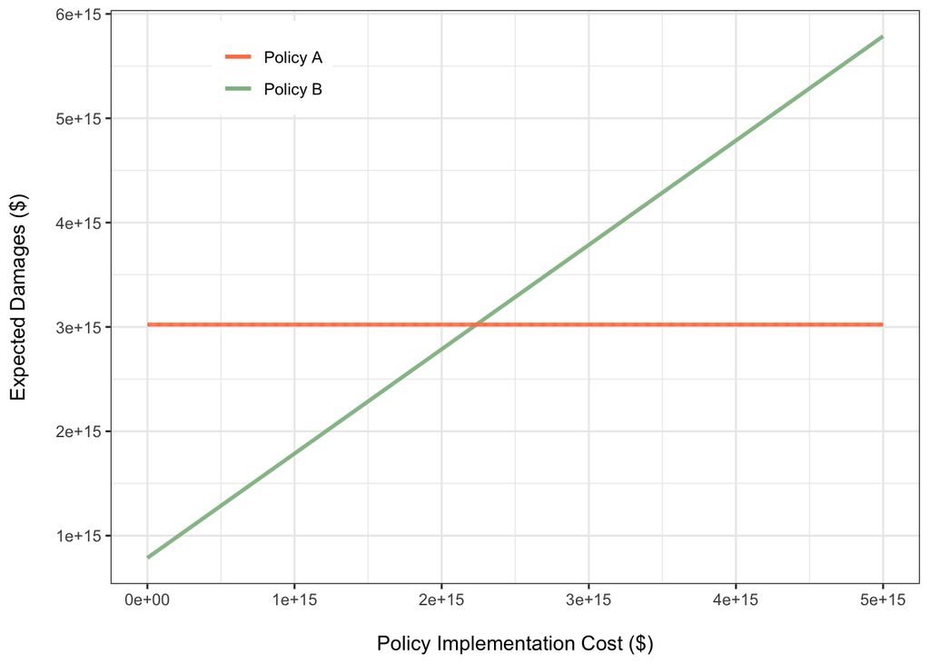

```r
# Create functions to find costs of both policies
policy_a_cost <- function(x){policy_a}
policy_b_cost <- function(x){policy_b+x}
costs <- seq(1e10,5e15,1e11) # Creating sequence to use for costs on correct scale

# Create function and use uniroot to find intersection where cost of Policy A = cost of Policy B
cost_difference_funct <- function(x){policy_a-(policy_b+x)}
equal_cost <- uniroot(cost_difference_funct, c(1e15,2.5e15))$root

# Plot the policy cost and damages together
ggplot(data.frame()) +
  geom_line(aes(x = costs, y = costs + policy_b, color = "Policy B"), size = 1) +
  geom_line(aes(x = costs, y = policy_a, color = "Policy A"), size = 1) +
  theme_bw() +
  scale_x_continuous(name ="\nPolicy Implementation Cost ($)") +
  scale_y_continuous(name ="Expected Damages ($)\n") +
  scale_color_manual(values = c("coral","darkseagreen")) +
theme(legend.title = element_blank(),
        legend.position = c(0.2, 0.9),
        legend.background = element_rect(size = 0.1))
```

**Figure 5:** The above plot shows the expected value of policies A and B as a function of the initial cost of implementing Policy B.

Policy A and Policy B have the same expected damages and implementation cost at approximately $2.2365743^{15}. Congress should implement Policy B up until that point, as it is less expensive to enact and has a lower risk. Society is risk neutral, but Policy B is still a better choice as long total costs remain below the intersection point of each policy.

# Question 6

Now suppose that society is risk averse. How do you think this would change your advice to Congress?